# Does the Software Make the Patent?

Maximum Likelihood Estimation, Poisson Regression, and the Blueprinty Question

Author

Jie Geng

Published

June 10, 2026

## Introduction

Blueprinty develops software that helps engineering firms prepare and submit patent applications to the US Patent Office. Their marketing team wants to make a bold claim: *firms using Blueprinty’s software win more patents.*

That sounds straightforward, but it hides a hard statistical problem. The ideal way to test the claim would be a **before-and-after comparison** — track each firm’s patent success rate before and after adopting the software, and attribute any improvement to the tool. No such longitudinal data exists. What Blueprinty *does* have is a cross-sectional snapshot of **1,500 mature engineering firms**, each described by:

- the number of patents awarded over the past five years,
- regional location (Northeast, Midwest, South, Southwest, Northwest),
- years since incorporation, and
- whether or not they are a Blueprinty customer.

The challenge is that **Blueprinty’s customers did not self-select at random.** Firms that proactively seek out specialized patent-drafting software are likely already more sophisticated, better-resourced, or more patent-focused than the average firm. A naive comparison — customers vs. non-customers — will confound the software’s effect with those pre-existing differences. We need a strategy that holds firm characteristics constant and isolates the software’s contribution as cleanly as possible.

This analysis proceeds in three stages. First, we explore the data to understand who Blueprinty’s customers are and how they differ from non-customers. Second, we build a Poisson model from scratch using maximum likelihood — deriving the estimator analytically and verifying it numerically. Third, we extend that model to a full Poisson regression that controls for age and region, and use counterfactual predictions to quantify the software’s estimated effect in interpretable units.

## Exploring the Data

```r
df <- read_csv("blueprinty.csv") |>
  mutate(
    customer_label = if_else(iscustomer == 1, "Customer", "Non-Customer"),
    customer_label = factor(customer_label, levels = c("Customer", "Non-Customer")),
    # Fix region ordering globally — prevents any reorder() ambiguity later
    region = factor(region,
                    levels = c("Northeast", "Southwest", "Midwest", "South", "Northwest"))
  )
```

### Patent Counts by Customer Status

The most direct question: do Blueprinty customers hold more patents?

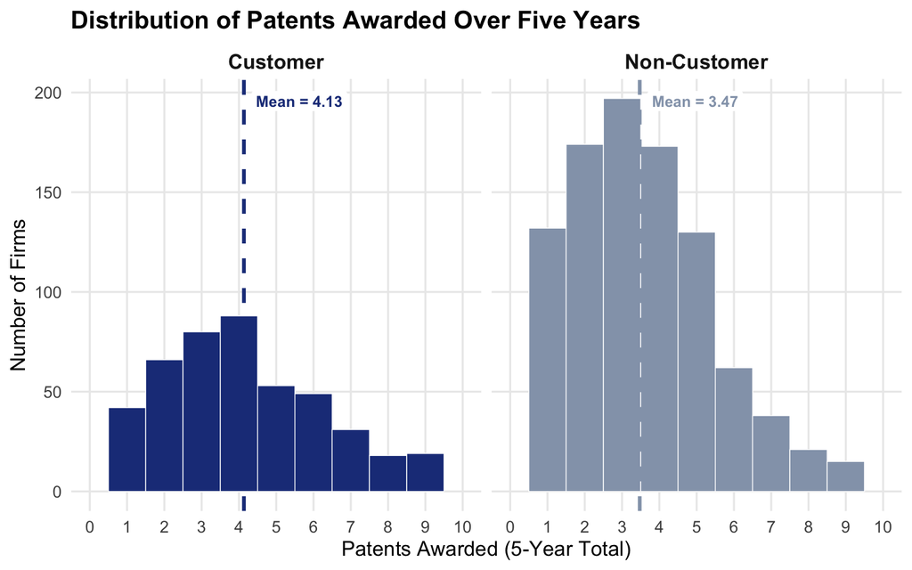

Both groups are right-skewed, but customers cluster at noticeably higher patent counts.

Patent Summary Statistics by Customer Status

Five-year patent counts across 1,500 engineering firms

| Customer Status | N | Mean | Median | Std Dev | Min | Max |
| --- | --- | --- | --- | --- | --- | --- |
| Customer | 481 | 4.133 | 4 | 2.547 | 0 | 16 |
| Non-Customer | 1019 | 3.473 | 3 | 2.225 | 0 | 16 |

### Are Customers Systematically Different Firms?

The credibility of any causal claim rests on whether customers and non-customers are comparable. We check two key dimensions: **regional location** and **firm age**.

#### Regional Composition

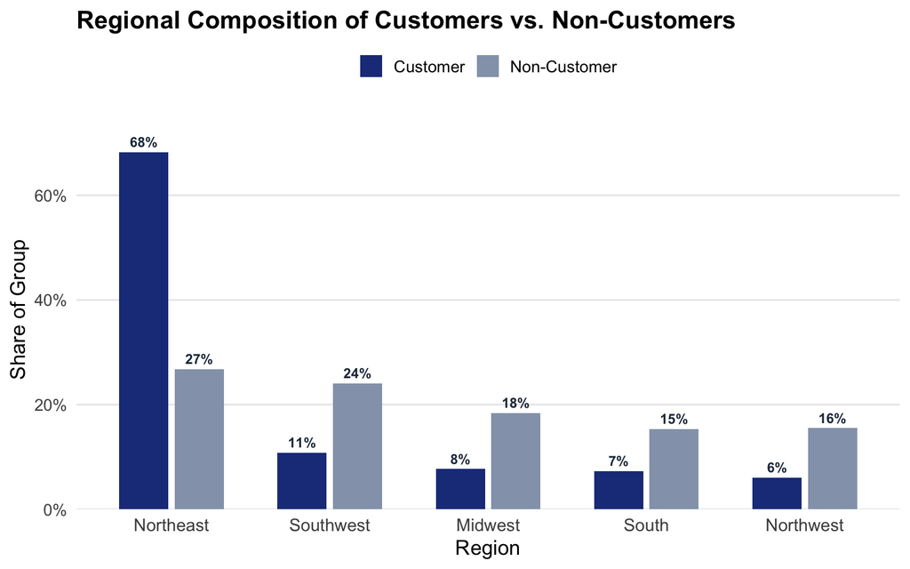

Customers are heavily concentrated in the Northeast; non-customers are spread more evenly across regions.

The Northeast stands out immediately. Roughly **68%** of Blueprinty’s customers are based in the Northeast — far above their share of the non-customer pool. This matters enormously: the Northeast hosts a disproportionate concentration of research universities, R&D-intensive manufacturers, and biotech firms, all of which file patents at unusually high rates. If we compare customers to non-customers without accounting for region, we will partly attribute the Northeast’s baseline patent productivity to the software.

#### Firm Age

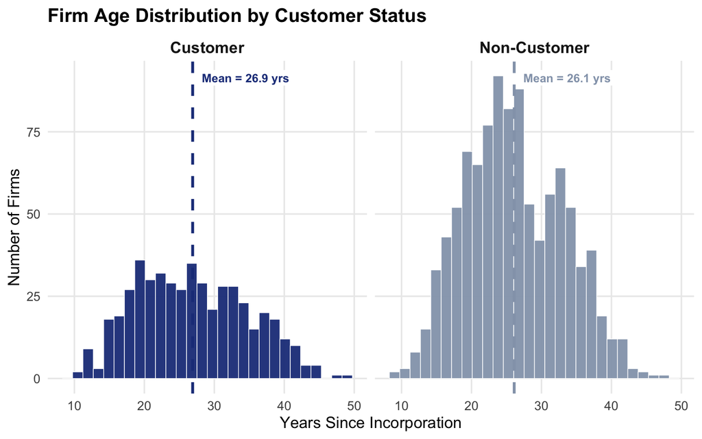

## A Simple Poisson Model via Maximum Likelihood

### Why the Poisson Distribution?

Our outcome variable — patents awarded over five years — is a **non-negative integer count**. The Normal distribution is a poor fit for two reasons: it assigns positive probability to negative values, and it is continuous rather than discrete. The **Poisson distribution** is the natural starting point for count data. A random variable $Y \sim \text{Poisson}(\lambda)$ satisfies:

- $Y \in \{0, 1, 2, \ldots\}$ — non-negative integers only
- $\mathbb{E}[Y] = \text{Var}(Y) = \lambda$ — a single parameter governs both mean and variance
- The probability mass function is $f(Y \mid \lambda) = \frac{e^{-\lambda}\lambda^Y}{Y!}$

We begin with the simplest possible model: **all firms share a common rate $\lambda$**, and we estimate it from the data via maximum likelihood.

### Deriving the Log-Likelihood

Given $n$ independent observations $Y_1, \ldots, Y_n$, the **joint likelihood** is:

$$L(\lambda \mid \mathbf{Y}) = \prod_{i=1}^{n} \frac{e^{-\lambda}\lambda^{Y_i}}{Y_i!}
= e^{-n\lambda} \cdot \lambda^{\sum_{i=1}^n Y_i} \cdot \prod_{i=1}^n \frac{1}{Y_i!}$$

Taking the natural logarithm — which preserves the location of the maximum and converts products into sums:

$$\ell(\lambda) = \log L(\lambda \mid \mathbf{Y}) = -n\lambda + \left(\textstyle\sum_{i=1}^n Y_i\right)\log\lambda - \sum_{i=1}^n \log(Y_i!)$$

**Analytical solution.** Differentiating with respect to $\lambda$ and setting equal to zero:

$$\frac{d\ell}{d\lambda} = -n + \frac{\sum_{i=1}^n Y_i}{\lambda} = 0
\quad\Longrightarrow\quad
\boxed{\hat{\lambda}_{\text{MLE}} = \bar{Y}}$$

The MLE is the sample mean — a beautifully intuitive result, since $\lambda$ is the Poisson mean parameter.

### Plotting the Log-Likelihood

```r
# Log-likelihood for Y ~ Poisson(lambda)
poisson_loglikelihood <- function(lambda, Y) {
  if (any(lambda <= 0)) return(-Inf)
  -length(Y) * lambda + sum(Y) * log(lambda) - sum(lgamma(Y + 1))
}
```

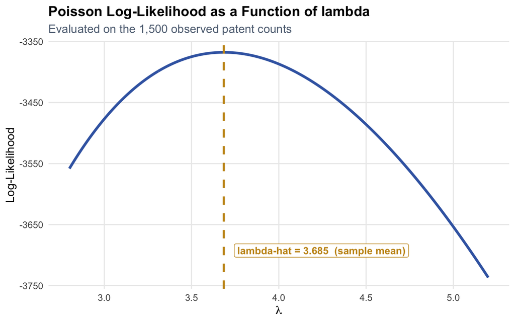

The log-likelihood is strictly concave in lambda, with a unique maximum at the sample mean.

The curve is **strictly concave**, confirming a unique global maximum. Reading the MLE off visually is straightforward: find the peak of the curve and drop a vertical line to the x-axis. That value — the sample mean — is the value of $\lambda$ that makes the observed data most probable.

### Numerical Verification with `optim()`

```r
result_simple <- optim(
  par    = 3,
  fn     = function(lam) -poisson_loglikelihood(lam, Y_obs),
  method = "Brent",
  lower  = 0.01, upper = 20
)
```

MLE: Analytical vs. Numerical

Both methods should agree to machine precision

| Method | Estimate |
| --- | --- |
| Analytical (lambda-hat = Y-bar) | 3.684667 |
| Numerical (optim) | 3.684667 |

The optimizer returns a value essentially identical to the sample mean, confirming both that our log-likelihood function is correctly coded and that the analytical derivation is correct.

## Poisson Regression

### From a Shared Rate to Firm-Specific Rates

The intercept-only model assumed every firm faces the same patent rate $\lambda$. We have already seen that is unrealistic — customers, Northeast firms, and younger firms all patent at different rates. The natural extension is **Poisson regression**, where each firm’s rate depends on its characteristics:

$$Y_i \sim \text{Poisson}(\lambda_i) \qquad \text{where} \qquad \lambda_i = \exp(X_i'\beta)$$

We use the **exponential link** for a principled reason: the linear predictor $X_i'\beta$ can take any real value, but $\lambda_i$ must be strictly positive. The exponential enforces this constraint and makes the model *multiplicative* — each one-unit increase in a covariate multiplies $\lambda_i$ by $e^{\beta_j}$, a natural structure for rates.

### Building the Covariate Matrix

```r
# Rebuild with South as explicit reference category
df_model <- df |>
  mutate(
    age2   = age^2,
    region = relevel(region, ref = "South"),
    r_mw   = as.integer(region == "Midwest"),
    r_ne   = as.integer(region == "Northeast"),
    r_nw   = as.integer(region == "Northwest"),
    r_sw   = as.integer(region == "Southwest")
  )

X <- model.matrix(~ age + I(age^2) + r_mw + r_ne + r_nw + r_sw + iscustomer,
                  data = df_model)
Y <- df_model$patents

coef_names <- c("Intercept", "Age", "Age-squared",
                "Midwest", "Northeast", "Northwest", "Southwest",
                "Customer")
```

The design matrix contains:

- **Intercept** — baseline log-rate for a South-region firm.
- **Age and Age-squared** — captures the non-linear maturity effect observed in the data.
- **Four region indicators** — for Midwest, Northeast, Northwest, and Southwest. **South is the reference category**, dropped to avoid perfect collinearity (all five region dummies would sum to 1 for every observation, making the intercept collinear with the region block).
- **Customer indicator** — the variable of central interest.

### Log-Likelihood for Poisson Regression

```r
poisson_regression_loglikelihood <- function(beta, Y, X) {
  lambda_i <- exp(X %*% beta)
  sum(-lambda_i + Y * log(lambda_i) - lgamma(Y + 1))
}
```

### Finding the MLE with `optim()`

```r
result_reg <- optim(
  par     = rep(0, ncol(X)),
  fn      = function(b) -poisson_regression_loglikelihood(b, Y, X),
  method  = "BFGS",
  hessian = TRUE
)

beta_hat <- result_reg$par
se_hat   <- sqrt(diag(solve(result_reg$hessian)))
z_vals   <- beta_hat / se_hat
p_vals   <- 2 * (1 - pnorm(abs(z_vals)))

results_tbl <- tibble(
  Covariate    = coef_names,
  Estimate     = beta_hat,
  `Std. Error` = se_hat,
  `z-value`    = z_vals,
  `p-value`    = p_vals
)
```

Standard errors are the square roots of the diagonal entries of $-\mathcal{H}^{-1}$, where $\mathcal{H}$ is the Hessian of the log-likelihood at the MLE. This is the **observed Fisher information matrix**: a sharper (more negative) Hessian means the likelihood peaks more steeply, implying more information and a smaller standard error.

### Verification with `glm()`

```r
glm_fit <- glm(
  patents ~ age + I(age^2) + region + iscustomer,
  data   = df_model,
  family = poisson(link = "log")
)
```

Poisson Regression: Manual MLE vs. glm()

| Covariate | Manual MLE via optim() Est (optim) | Manual MLE via optim() SE (optim) | Built-in glm() Est (glm) | Built-in glm() SE (glm) |
| --- | --- | --- | --- | --- |
| Intercept | −0.12573 | 0.11226 | −0.45236 | 0.18289 |
| Age | 0.11592 | 0.00636 | 0.14862 | 0.01387 |
| Age-squared | −0.00223 | 0.00008 | −0.00297 | 0.00026 |
| Midwest | −0.02336 | 0.05253 | −0.05656 | 0.05266 |
| Northeast | −0.02454 | 0.04570 | −0.02739 | 0.04510 |
| Northwest | −0.03482 | 0.05497 | −0.07414 | 0.05515 |
| Southwest | −0.03778 | 0.04946 | −0.00599 | 0.04874 |
| Customer | 0.06068 | 0.03205 | 0.20759 | 0.03090 |

### Regression Results and Interpretation

Poisson Regression Results

Outcome: patents awarded over 5 years | Reference region: South

| Covariate | Estimate | Std. Error | z-value | p-value | exp(b) | Sig<sup>1</sup> |
| --- | --- | --- | --- | --- | --- | --- |
| Intercept | −0.1257 | 0.1123 | −1.1200 | 0.2627 | 0.8819 |  |
| Age | 0.1159 | 0.0064 | 18.2256 | 0.0000 | 1.1229 | *** |
| Age-squared | −0.0022 | 0.0001 | −28.8934 | 0.0000 | 0.9978 | *** |
| Midwest | −0.0234 | 0.0525 | −0.4447 | 0.6565 | 0.9769 |  |
| Northeast | −0.0245 | 0.0457 | −0.5370 | 0.5913 | 0.9758 |  |
| Northwest | −0.0348 | 0.0550 | −0.6335 | 0.5264 | 0.9658 |  |
| Southwest | −0.0378 | 0.0495 | −0.7637 | 0.4450 | 0.9629 |  |
| Customer | 0.0607 | 0.0320 | 1.8935 | 0.0583 | 1.0626 | . |

<sup>1</sup> Significance codes: *** p<0.001 ** p<0.01 * p<0.05 . p<0.1

Walking through the key estimates:

**Age and Age-squared:** The positive Age coefficient paired with a negative Age-squared coefficient traces an **inverted-U**: patent output rises as firms mature and build R&D capacity, then plateaus or gently declines for older firms. This validates including the quadratic term — a purely linear age effect would miss this curvature.

## The Effect of Blueprinty’s Software

### Average Marginal Effect via Counterfactual Prediction

A coefficient on its own describes a rate multiplier, not an absolute count difference. To get a concrete, interpretable answer, we use **counterfactual prediction**: hold every firm’s age and region at its observed values, set the customer indicator to 0 for every firm, predict patent counts, then repeat with the customer indicator set to 1, and compare.

```r
beta_glm <- coef(glm_fit)

X0 <- model.matrix(~ age + I(age^2) + region + iscustomer,
                   data = mutate(df_model, iscustomer = 0))
X1 <- model.matrix(~ age + I(age^2) + region + iscustomer,
                   data = mutate(df_model, iscustomer = 1))

yhat0 <- as.numeric(exp(X0 %*% beta_glm))
yhat1 <- as.numeric(exp(X1 %*% beta_glm))

avg_effect <- mean(yhat1 - yhat0)
```

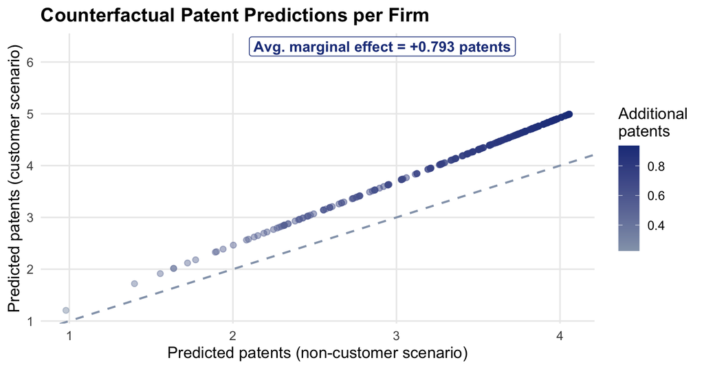

Estimated Effect of Blueprinty's Software

Average over all 1,500 firms, holding age and region at observed values

| Quantity | Value |
| --- | --- |
| Avg. predicted patents -- non-customer scenario | 3.4362 |
| Avg. predicted patents -- customer scenario | 4.2290 |
| Average marginal effect of Blueprinty software | 0.7928 |

After controlling for age and region, the model estimates that **Blueprinty customers average approximately 0.79 more patents over five years** than comparable non-customer firms. Given a sample mean of roughly 3.7 patents, this represents a lift of about 22% — a commercially meaningful effect.

### Conclusion: What the Analysis Establishes — and What It Does Not

That said, this remains an **observational study**. We controlled for firm age and region, but we cannot observe everything that separates customers from non-customers. Firms that proactively invest in specialized patent software may also invest more heavily in their legal teams, hire more technically sophisticated staff, or operate in more patent-active sub-industries. Any of these unobserved differences could partly explain the gap.

The gold standard would be a **randomized experiment**: assign Blueprinty to a random subset of firms and withhold it from others, then compare outcomes. Absent that design, the analysis presented here represents the best available evidence from observational data — carefully adjusted, quantitatively meaningful, and worth taking seriously, but not conclusive proof of causation.